# VTPEH 6270 - Data Wrangling and Visualization

Amandine Gamble

2026-02-02

# 1 Introduction

We will use the [CDC Malaria data](https://data.cdc.gov/Global-Health/Number-of-Reported-Malaria-Cases-by-County-United-/puzh-5wax/about_data), and the [CDC Social Vulnerability Index (SVI) data](https://www.atsdr.cdc.gov/place-health/php/svi/svi-data-documentation-download.html).

```r
data_malaria = read.csv("Data/Number_of_Reported_Malaria_Cases_by_County__United_States__2017_20250120.csv")
data_svi = read.csv("Data/SVI_2016_US_county.csv")
```

# 2 Merging data sets

## 2.1 Uniformizing variable names

Check variables are labelled the same way. If not, uniformize.

```r
colnames(data_malaria)
colnames(data_svi)
```

## 2.2 Uniformizing value codes

Check values are coded the same way. If not, uniformize.

```r
unique(data_malaria$COUNTY)
unique(data_svi$COUNTY)

data_svi$COUNTY = toupper(data_svi$COUNTY)
unique(data_svi$COUNTY)
```

## 2.3 Merging

```r
data_merged = merge(data_malaria, data_svi, by = "COUNTY", all.x = T)
View(data_merged)

data_merged = merge(data_malaria, data_svi, by = c("COUNTY", "STATE"), all.x = T)
```

Check output at each stage!

# 3 Data visualization - Scatter plots

```r
library(ggplot2)
```

## 3.1 Base plot

Plot of county Malaria cases ~ county population. Make sure the labels are explicit.

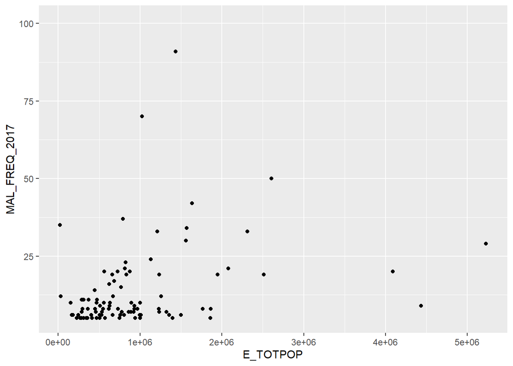

```r
ggplot(data_merged, aes(x = E_TOTPOP, y = MAL_FREQ_2017)) +
  geom_point()
```

Don’t forget to check the missing data.

Improve…

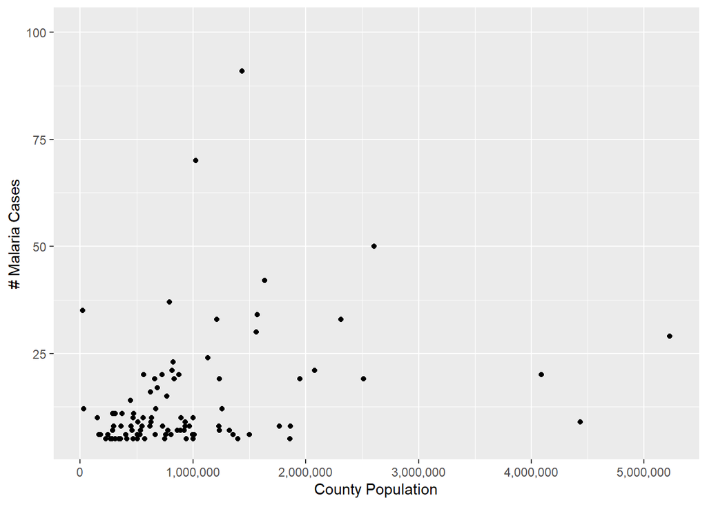

```r
ggplot(data_merged, aes(x = E_TOTPOP, y = MAL_FREQ_2017)) +
  geom_point() +
  scale_x_continuous(
    breaks = seq(0, 5000000, 1000000),
    labels = scales::comma
  ) +
  labs(
    x = "County Population",
    y = "# Malaria Cases"
  )
```

## 3.2 Design

For instance, change the theme, and adjust to remove the grid.

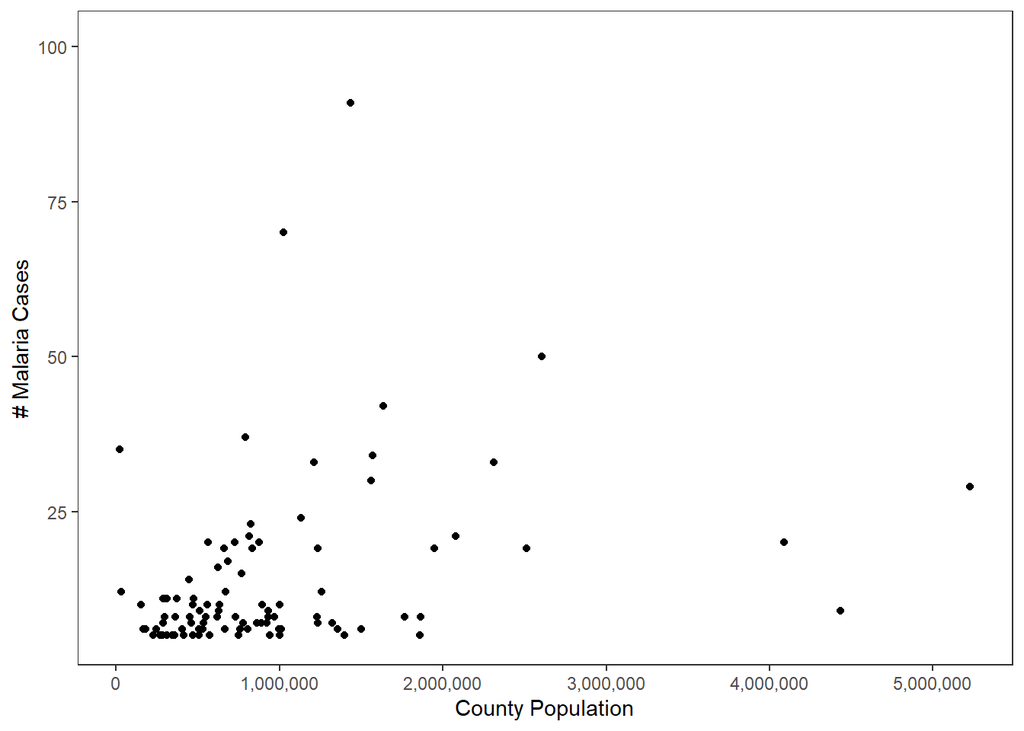

```r
ggplot(data_merged, aes(x = E_TOTPOP, y = MAL_FREQ_2017)) +
  geom_point() +
  scale_x_continuous(
    breaks = seq(0, 5000000, 1000000),
    labels = scales::comma
  ) +
  labs(
    x = "County Population",
    y = "# Malaria Cases"
  ) +
  theme_bw() +
  theme(panel.grid = element_blank())
```

## 3.3 Adding information

We want to know which state each point corresponds to…

How many dimension is that? How can we show it?

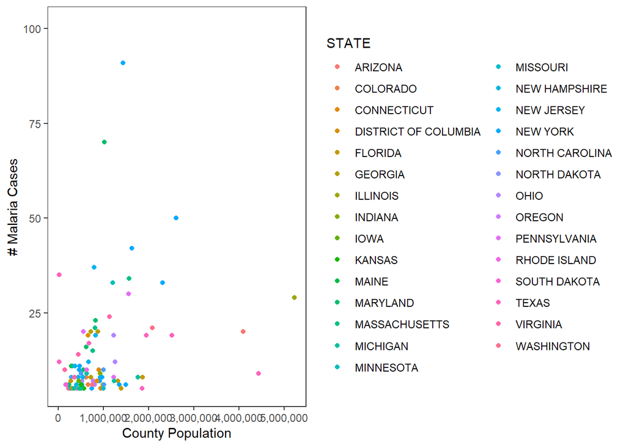

```r
ggplot(data_merged, aes(x = E_TOTPOP, y = MAL_FREQ_2017, colour = STATE)) +
  geom_point() +
  scale_x_continuous(
    breaks = seq(0, 5000000, 1000000),
    labels = scales::comma
  ) +
  labs(
    x = "County Population",
    y = "# Malaria Cases"
  ) +
  theme_bw() +
  theme(panel.grid = element_blank())
```

Try something else…

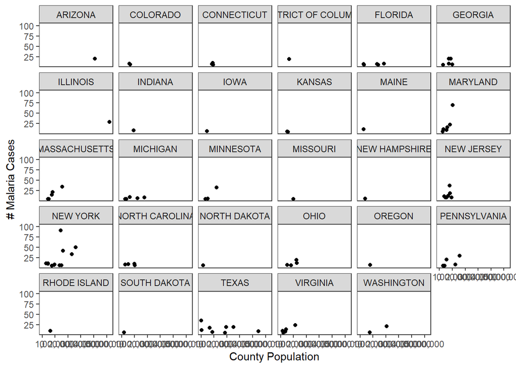

```r
ggplot(data_merged, aes(x = E_TOTPOP, y = MAL_FREQ_2017)) +
  geom_point() +
  scale_x_continuous(
    breaks = seq(0, 5000000, 1000000),
    labels = scales::comma
  ) +
  labs(
    x = "County Population",
    y = "# Malaria Cases"
  ) +
  facet_wrap(STATE ~ .) +
  theme_bw() +
  theme(panel.grid = element_blank())
```

Improve…

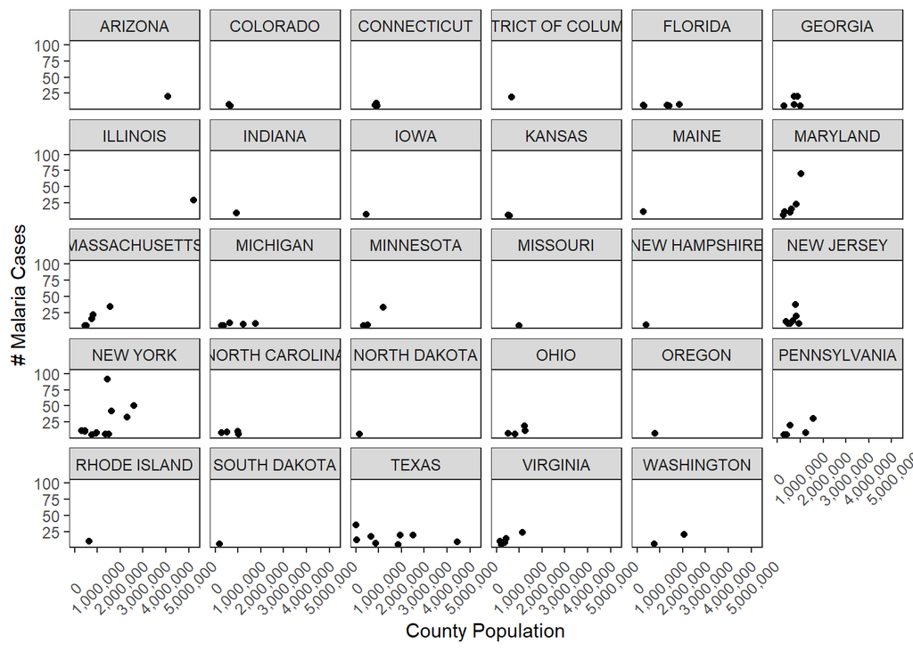

```r
ggplot(data_merged, aes(x = E_TOTPOP, y = MAL_FREQ_2017)) +
  geom_point() +
  scale_x_continuous(
    breaks = seq(0, 5000000, 1000000),
    labels = scales::comma
  ) +
  labs(
    x = "County Population",
    y = "# Malaria Cases"
  ) +
  facet_wrap(STATE ~ .) +
  theme_bw() +
  theme(panel.grid = element_blank(), axis.text.x = element_text(angle = 45, vjust = 0.5))
```

Improve…

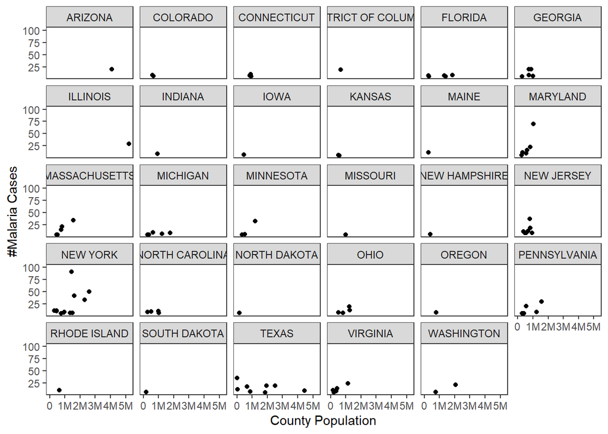

```r
ggplot(data_merged, aes(x = E_TOTPOP, y = MAL_FREQ_2017)) +
  geom_point() +
  scale_x_continuous(
    breaks = seq(0, 5000000, 1000000),
    labels = c(0, "1M", "2M", "3M", "4M", "5M")
  ) +
  labs(
    x = "County Population",
    y = "#Malaria Cases"
  ) +
  facet_wrap(STATE ~ .) +
  theme_bw() +
  theme(panel.grid = element_blank())
```

Improve…

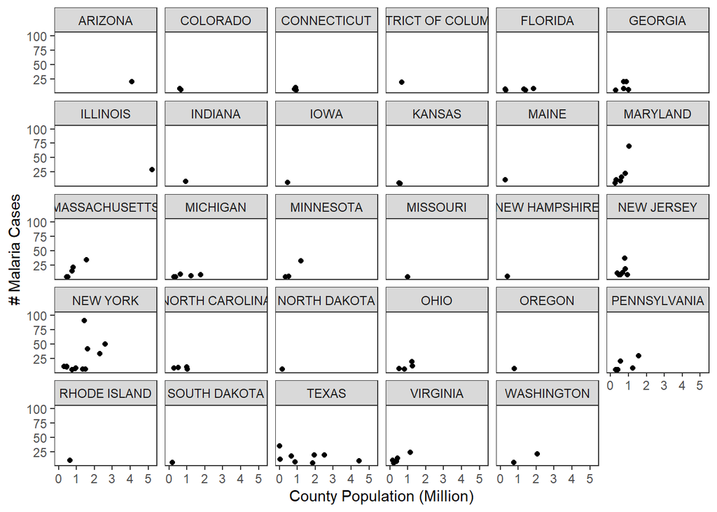

```r
ggplot(data_merged, aes(x = E_TOTPOP, y = MAL_FREQ_2017)) +
  geom_point() +
  scale_x_continuous(
    breaks = seq(0, 5000000, 1000000),
    labels = seq(0, 5)
  ) +
  labs(
    x = "County Population (Million)",
    y = "# Malaria Cases"
  ) +
  facet_wrap(STATE ~ .) +
  theme_bw() +
  theme(panel.grid = element_blank())
```

## 3.4 Side note - Subsetting data setls

Ok let’s focus on the the states with 5 or more counties represented…

```r
# Count occurrences
table(data_merged$STATE)

# Identify the states with 5 or more observations
which(table(data_merged$STATE) >= 5)

# Find their names
names(which(table(data_merged$STATE) >= 5))

# Subset from the data frame
data_merged_sub = data_merged[is.element(data_merged$STATE,
                                         names(which(table(data_merged$STATE) >= 5))), ]
```

Check the output…

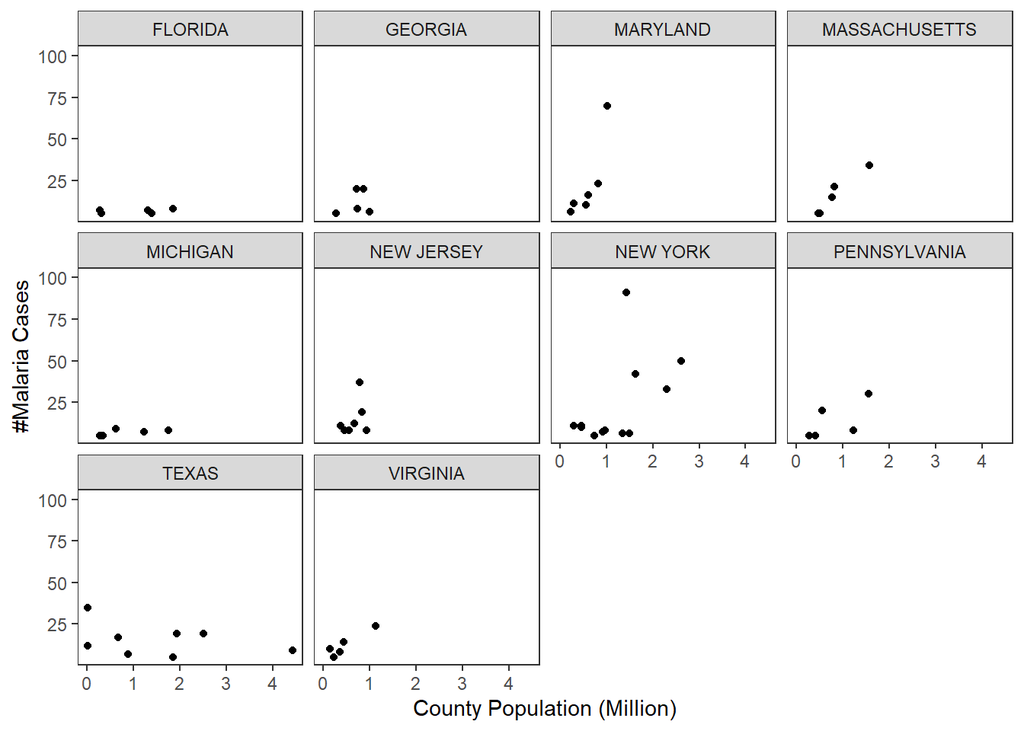

```r
ggplot(data_merged_sub, aes(x = E_TOTPOP, y = MAL_FREQ_2017)) +
  geom_point() +
  scale_x_continuous(
    breaks = seq(0, 5000000, 1000000),
    labels = seq(0, 5)
  ) +
  labs(
    x = "County Population (Million)",
    y = "#Malaria Cases"
  ) +
  facet_wrap(STATE ~ .) +
  theme_bw() +
  theme(panel.grid = element_blank())
```

## 3.5 Adding information

We want to add information on the number of people below the poverty estimate…

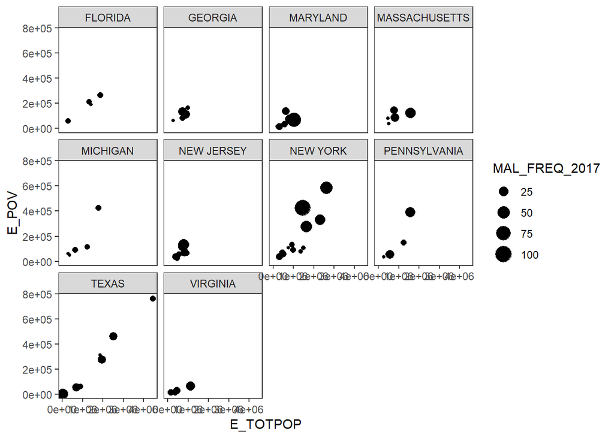

```r
ggplot(data_merged_sub, aes(x = E_TOTPOP, y = E_POV, size = MAL_FREQ_2017)) +
  geom_point() +
  facet_wrap(STATE ~ .) +
  theme_bw() +
  theme(panel.grid = element_blank())
```

Improve…

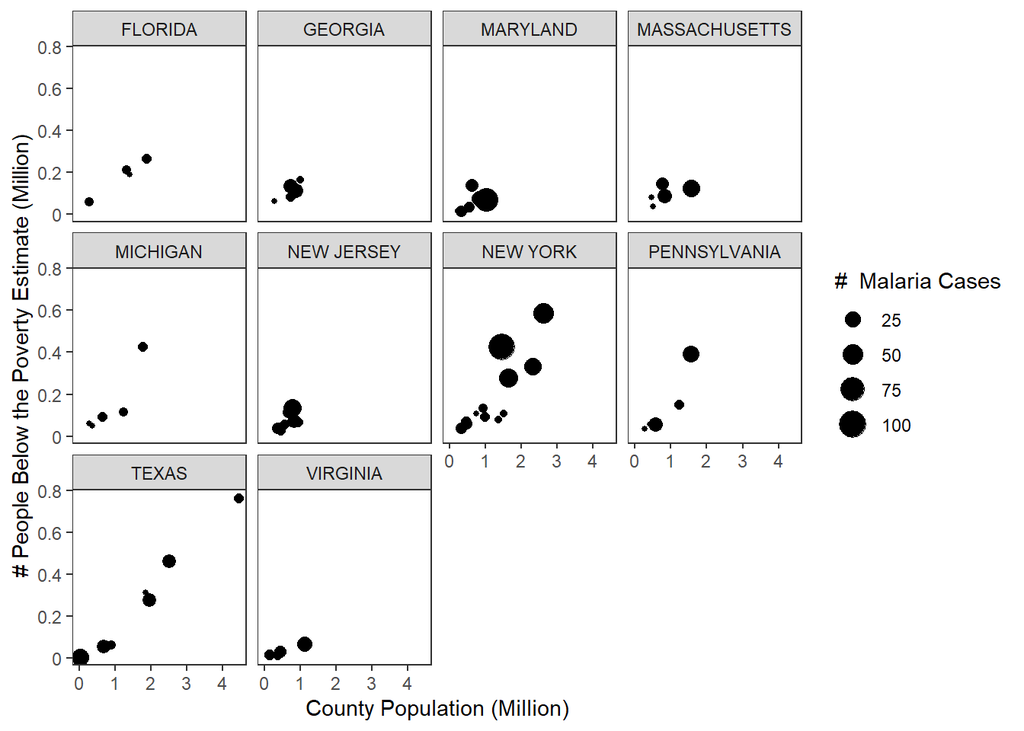

```r
ggplot(data_merged_sub, aes(x = E_TOTPOP, y = E_POV, size = MAL_FREQ_2017)) +
  geom_point() +
  scale_x_continuous(
    breaks = seq(0, 5000000, 1000000),
    labels = seq(0, 5)
  ) +
    scale_y_continuous(
    breaks = seq(0, 800000, 200000),
    labels = seq(0, 0.8, 0.2)
  ) +
  labs(
    x = "County Population (Million)",
    y = "# People Below the Poverty Estimate (Million)"
  ) +
  scale_size(name = "#  Malaria Cases") +
  facet_wrap(STATE ~ .) +
  theme_bw() +
  theme(panel.grid = element_blank())
```

How many dimensions are we working with now?

Think about what it means…

# 4 Data visualization - Distributions

## 4.1 Base plot

Plot of county population distribution across states.

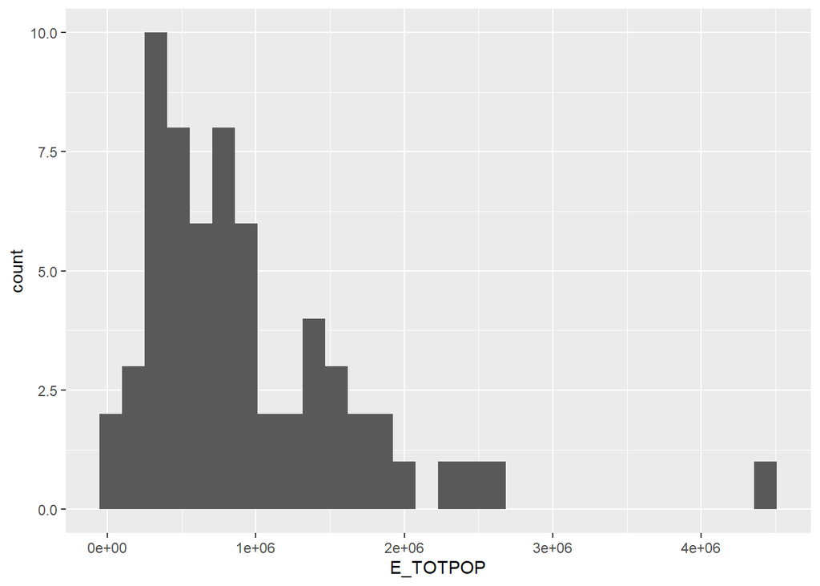

```r
ggplot(data_merged_sub, aes(x = E_TOTPOP)) +
  geom_histogram()
```

## 4.2 Adding information

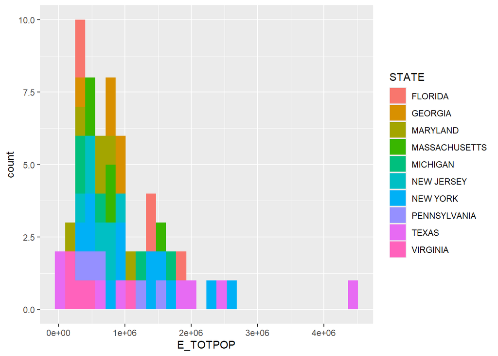

```r
ggplot(data_merged_sub, aes(x = E_TOTPOP, fill = STATE)) +
  geom_histogram()
```

Nope…

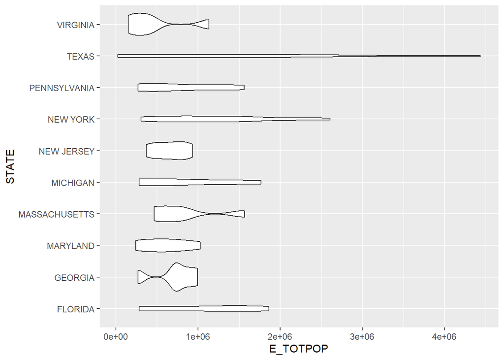

```r
ggplot(data_merged_sub, aes(x = E_TOTPOP, y = STATE)) +
  geom_violin()
```

Works but not very nice…

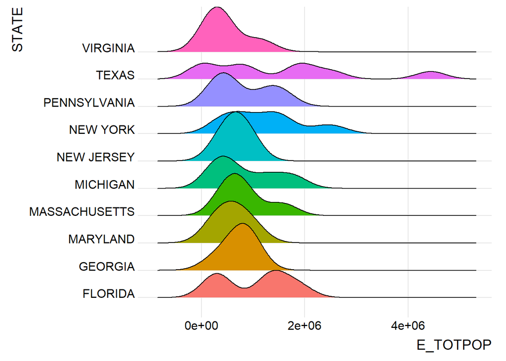

```r
library(ggridges)

ggplot(data_merged_sub, aes(x = E_TOTPOP, y = STATE, fill = STATE)) +
  geom_density_ridges() +
  theme_ridges() +
  theme(legend.position = "none")
```

Fine tune.

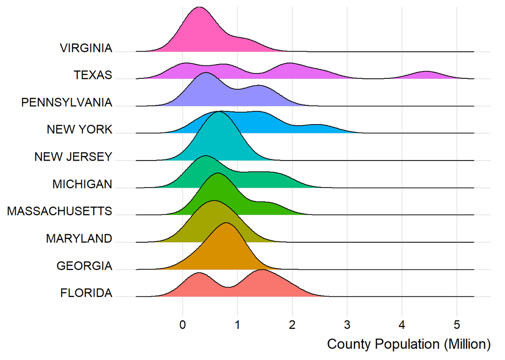

```r
ggplot(data_merged_sub, aes(x = E_TOTPOP, y = STATE, fill = STATE)) +
  geom_density_ridges() +
    scale_x_continuous(
    breaks = seq(0, 5000000, 1000000),
    labels = seq(0, 5)
  ) +
    labs(
    x = "County Population (Million)"
  ) +
  theme_ridges() +
  theme(legend.position = "none",
        axis.title.y = element_blank())
```

Think about what it means…

# 5 Data visualization - High throughput exploration of high-dimensionality data

Ideally, you should start you project with strong hypotheses regarding associations between variables. But it’s not always the case, sometimes there’s just too many variables… It can be especially overwhelming when it is not your data. Data visualization is always the best way to get to know your data.

Let’s look at the SVI data set as a whole…

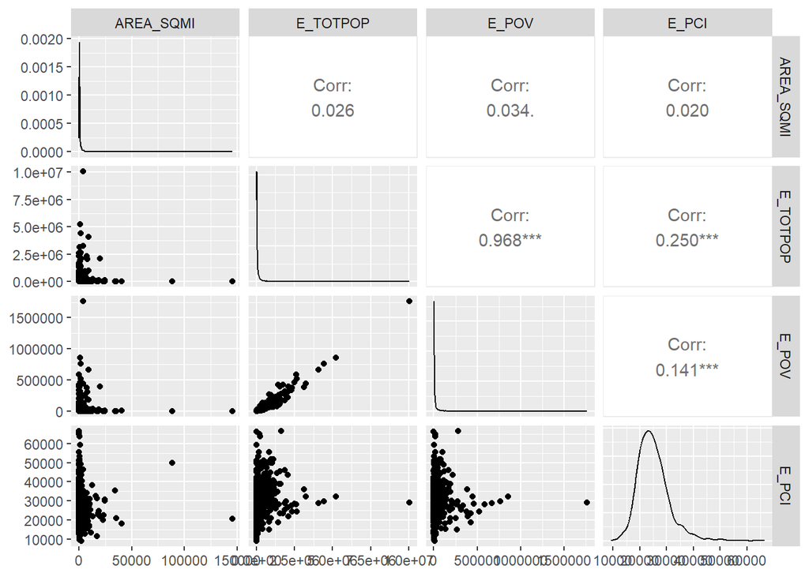

```r
library(GGally)

colnames(data_svi)

ggpairs(data_svi[, c("AREA_SQMI", "E_TOTPOP", "E_POV", "E_PCI")])
```

# 6 Resources

- [ggplot2 Resources](https://ggplot2.tidyverse.org/)
- [r-graph-gallery](https://r-graph-gallery.com/)
- [patchwork Resources](https://patchwork.data-imaginist.com/)